# BMIN503/EPID600 Final Project Madeleine: The Relationship Between Diabetes and Dental Health

Madeleine Salwen

# Overview

The purpose of this project is to explore the relationship between dental health and Type 1 diabetes diagnosis considering possible co-variates such as smoking and food insecurity. To do so, I will be using NHANES data from the past 18 years (minus the covid years). My two advisors are Blanca Himes, PhD, Epidemiology, and Kira Nightingale from the epidemiology department who works in the dental school. Dr Himes has been very helpful in figuring out the question and how to use the NHANES data. Kira Nightingale was vital in assisting me with the dmft score as a metric of dental health.

https://github.com/msalwen19/BMIN503_Final_Project

# Introduction

Diet is a vital tool in type 1 diabetes management in order to keep blood glucose levels near normal. Technological advancements in insulin therapies such as insulin pumps and flexible injection regiments have drastically improved the lifestyle of children and adults with diabetes. It is still necessary to calculate carbohydrate intake at each meal to account for the appropriate amount of insulin. A review by Rovner suggests that children with diabetes eat more processed foods because packaged items are appealing to facilitate carbohydrate counting. (1) In instances of hypoglycemia, fast acting carbohydrates are required to quickly raise glucose levels. Often, simple sugars like glucose tablets or skittles and other candy are used because they provide fast acting relief. (2) Overall, these dietary practices may affect dental health. Countless studies have shown the relationship between sugar intake and an increased risk of dental caries. Processed foods also tend to contain more sugar, or additives that can damage oral health. Lastly, the higher glucose levels in blood, is also true in saliva, creating an ideal breeding ground for bacteria in the mouth. (3) There is precedent for the relationship between diabetes and dental health, however, my research has only seen instances of type 2 diabetes or diabetes in general investigated. I am interested in specifically isolated type 1 cases to see if these could be statistically significant from type 2 as the diseases have different mechanisms.

This issue can be understood through an interdisciplinary approach. Diabetes and dental health must be investigated through a broader public health lens to account for factors such as access to dental care, smoking status, and food insecurity in addition to the clinical factors of dental outcomes and diabetes type. I will use the NHANES data set over multiple years, and practices of statistical models to investigate the data. Fields that can contribute to this understanding are epidemiological, statistical, dental, and endocrine.

# Methods

This report incorporates theNHANES questionnaire and examination data sets from 2001 - 2018. Covid years were not considered due to complications of missing and repeated data. Data cleaning was necessary to isolate variables and rename factors to represent desired data.

### Useful packages

```r
install.packages("nhanesA")
install.packages("plyr")
install.packages("rgdal")
install.packages("sf")
install.packages("tidycensus")
install.packages("ggsn")
install.packages("leaflet")
```

```r
library(nhanesA)#nhanes data
library(plyr) #cleaning
library(dplyr) #cleaning
library(tidyverse)
library(ggplot2) #plots
library(GGally)
library(gtsummary) #nice table
library(ggforce) #for the zoom on the graph
library(modelsummary)
library(lemon) #to print pretty data frames
```

## Loading in the data

```r
varlist <- c("DEMO", "DIQ", "OHQ", "SMQ", "FSQ")
varlist_years <- paste0(rep(varlist, each = 9), c("_B", "_C", "_D", "_E","_F","_G","_H","_I","_J")) #creates a list with the necessary data sets with which to call in the next step
list_all <- sapply(varlist_years, function(x) {data.frame(nhanes(x))}) #loads in data from the R package nhanes for the chosen data sets and years

#Create a data frame for each section of questions ex DEMO
for(i in 1:length(list_all)) {
  assign(names(list_all)[i], list_all[[i]])
}

#Combine section questions from each year into one larger data frame and remove the year individual data frames
for (i in 1:length(varlist)) {
  assign(varlist[i], plyr::rbind.fill(mget(grep(varlist[i], ls(), value = T))))
}
rm(list = grep("_[BCDEFGHIJ]", ls(), value = T)) #cleans the environment

nhanes.data <- full_join(get(varlist[1]), get(varlist[2]), by = "SEQN") #join the data frames. only 2 can be joined at a time.
```

## Cleaning the data

```r
nhanes.data <- nhanes.data %>%
  dplyr::rename(have_diabetes = DIQ010, age_when_diagnosed = DID040,
                taking_insulin = DIQ050, how_long_insulin = DID060, A1C = DIQ280,
                take_metformin = DIQ070) %>%
  dplyr::rename(house_income = INDHHIN2, pregnant = RIDEXPRG) %>%
  dplyr::rename(sex = RIAGENDR, age = RIDAGEYR,
           race = RIDRETH1, education = DMDEDUC2) %>%
  dplyr::mutate(sex = factor(sex, levels = c(1, 2),
                           labels = c("men", "women"))) %>%
  dplyr::mutate(race = factor(race, levels = c(3, 1, 2, 4, 5),
                         labels = c("White", "MexicanAmerican",
                                    "Hispanic", "Black", "Other"))) %>%
  dplyr::mutate(education = factor(education, levels = c(1,2,3,4,5,7,9),
                                   labels = c("< 9th grade", "9-11th", "HS or GED",
                                              "some college or AA", ">= college graduate",
                                              "refused", "don't know")))

nhanes.data <- nhanes.data %>%
  dplyr::select(-contains(c("DIQ", "DID", "DMD", "IND", "DMQ", "RID", "WT"))) %>% #deletes everything that contains words that I found I didn't want
  dplyr::select(-FIAINTRP, -FIALANG, - FIAPROXY,  -MIAINTRP,
                -MIALANG, -MIAPROXY, -AIALANG, -AIALANGA,
                -SDDSRVYR, -SDMVPSU, -SDMVSTRA, -SIAINTRP, -SIALANG, -SIAPROXY) #and deleting the rest of variables I didn't want

#OHQ data
OHQ <- OHQ %>%
  dplyr::rename(taste_affect = OHQ650, avoid_food = OHQ660, difficulty_eating = OHQ670) %>%
  dplyr::rename(tooth_loose = OHQ855, tooth_looks_wrong = OHQ865) %>%
  dplyr::rename(last_dentist = OHQ030, fluoride = OHQ566, aching = OHQ620, difficulty_bc_teeth = OHQ640,
           embarrassed_bc_teeth = OHQ680, not_recieve_dental = OHQ770,
           reason_no_dental_cost = OHQ780A, reason_no_dental_money = OHQ780B,
           reason_no_dental_insurance = OHQ780C, reason_no_dental_distance = OHQ780D,
           reason_no_dental_open = OHQ780E, reason_no_dental_recommended = OHQ780F,
           reason_no_dental_afraid = OHQ780G, reason_no_dental_work = OHQ780H,
           reason_no_dental_busy = OHQ780I,reason_no_dental_dissapear = OHQ780J,
           reason_no_dental_other = OHQ780K,
           gum_disease = OHQ835, rate_dental_health = OHQ845,
           gum_disease_treatment = OHQ850, lost_bone = OHQ860)

OHQ <- OHQ %>%
  dplyr::mutate(gum_disease = factor(gum_disease, levels = c(1,2,7,9),
                                   labels = c("Yes", "No", "Refused", "Don't know"))) %>%
  dplyr::mutate(rate_dental_health = factor(rate_dental_health, levels = c(1,2,3, 4, 5, 7,9),
                                   labels = c("Excellent", "Very Good", "Good",
                                              "Fair", "Poor", "Refused", "Don't know"))) %>%
  dplyr::mutate(gum_disease_treatment = factor(gum_disease_treatment, levels = c(1,2,7,9),
                                   labels = c("Yes", "No", "Refused", "Don't know"))) %>%
  dplyr::mutate(tooth_loose = factor(tooth_loose, levels = c(1,2,7,9),
                                   labels = c("Yes", "No", "Refused", "Don't know"))) %>%
  dplyr::mutate(lost_bone = factor(lost_bone, levels = c(1,2,7,9),
                                   labels = c("Yes", "No", "Refused", "Don't know"))) %>%
  dplyr::mutate(tooth_looks_wrong = factor(tooth_looks_wrong, levels = c(1,2,7,9),
                                   labels = c("Yes", "No", "Refused", "Don't know"))) %>%
  dplyr::mutate(last_dentist = factor(last_dentist, levels = c(1,2,3, 4, 5, 6, 7, 77, 99),
                                   labels = c("<6mo", "6mo < x < 1yr", "1yr < x < 2yr",
                                              "2yr < x < 3yr", "3yr < x < 5yr", ">5yr",
                                              "Never", "Refused", "Don't know"))) %>%
  dplyr::mutate(aching = factor(aching, levels = c(1,2,3, 4, 5, 7,9),
                                   labels = c("Very Often", "Fairly Often", "Occasionally",
                                              "Hardly Ever", "Never", "Refused",
                                              "Don't know"))) %>%
  dplyr::mutate(difficulty_bc_teeth = factor(difficulty_bc_teeth, levels = c(1,2,3, 4, 5, 7,9),
                                   labels = c("Very Often", "Fairly Often", "Occasionally",
                                              "Hardly Ever", "Never", "Refused",
                                              "Don't know"))) %>%
  dplyr::mutate(embarrassed_bc_teeth = factor(embarrassed_bc_teeth, levels = c(1,2,3, 4, 5, 7,9),
                                   labels = c("Very Often", "Fairly Often", "Occasionally",
                                              "Hardly Ever", "Never", "Refused",
                                              "Don't know"))) %>%
  dplyr::mutate(taste_affect = factor(taste_affect, levels = c(1,2,3, 4, 5, 7,9),
                                   labels = c("Very Often", "Fairly Often", "Occasionally",
                                              "Hardly Ever", "Never", "Refused",
                                              "Don't know"))) %>%
  dplyr::mutate(avoid_food = factor(avoid_food, levels = c(1,2,3, 4, 5, 7,9),
                                   labels = c("Very Often", "Fairly Often", "Occasionally",
                                              "Hardly Ever", "Never", "Refused",
                                              "Don't know"))) %>%
  dplyr::mutate(difficulty_eating = factor(difficulty_eating, levels = c(1,2,3, 4, 5, 7,9),
                                   labels = c("Very Often", "Fairly Often", "Occasionally",
                                              "Hardly Ever", "Never", "Refused",
                                              "Don't know")))

OHQ <- OHQ %>%
  dplyr::select(-contains(c("OHQ", "OHD")))
#join OHQ
nhanes.data <- nhanes.data %>%
    full_join(OHQ, by = "SEQN")

#SMQ data
SMQ <- SMQ %>%
  dplyr::select(SMQ020, SMD030, SMQ040, SMQ900, SEQN) %>%
  dplyr::rename(hundred_cigs = SMQ020, smoke_cigs = SMQ040, e_cigs = SMQ900, age_started_smoking = SMD030) %>%
  dplyr::mutate(hundred_cigs = factor(hundred_cigs, levels = c(1, 2, 7,9),
                           labels = c("yes", "no", "refused", "don't know"))) %>%
  dplyr::mutate(smoke_cigs = factor(smoke_cigs, levels = c(1, 2, 3, 7,9),
                           labels = c("everyday", "some days", "not at all",
                                      "refused", "don't know"))) %>%
  dplyr::mutate(e_cigs = factor(e_cigs, levels = c(1, 2, 7,9),
                           labels = c("yes", "no", "refused", "don't know")))
#join SMQ with the other data frame
nhanes.data <- nhanes.data %>%
    full_join(SMQ, by = "SEQN")

#FSQ data
FSQ <- FSQ %>%
  dplyr::select(FSD032A, FSD032B, FSD032C, FSDAD, FSDCH, FSD041, FSD052, SEQN) %>%
  dplyr::rename(worried_run_out = FSD032A, food_didnt_last = FSD032B,
                no_balanced_meals = FSD032C, adult_food_security = FSDAD,
                child_food_security = FSDCH, skip_meals = FSD041,
                how_often_skip_meals = FSD052)
FSQ <- FSQ %>%
  dplyr::mutate(worried_run_out = factor(worried_run_out, levels = c(1,2,3, 7, 9),
                                   labels = c("Often True", "Sometimes True",
                                              "Never True", "Refused",
                                              "Don't know"))) %>%
  dplyr::mutate(food_didnt_last = factor(food_didnt_last, levels = c(1,2,3, 7, 9),
                                   labels = c("Often True", "Sometimes True",
                                              "Never True", "Refused",
                                              "Don't know"))) %>%
  dplyr::mutate(no_balanced_meals = factor(no_balanced_meals, levels = c(1,2,3,7, 9),
                                   labels = c("Often True", "Sometimes True",
                                              "Never True", "Refused",
                                              "Don't know"))) %>%
  dplyr::mutate(skip_meals = factor(skip_meals, levels = c(1, 2, 7,9),
                           labels = c("yes", "no", "refused", "don't know"))) %>%
  dplyr::mutate(adult_food_security = factor(adult_food_security, levels = c(1,2,3,4),
                           labels = c("full", "marginal", "low", "very low")))

#join FSQ with the other data frame
nhanes.data <- nhanes.data %>%
    full_join(FSQ, by = "SEQN")
```

## Creating a new column for diabetes type

Categorization was required to introduce a new variable diabetes_type. This variable attempted to distinguish between type 1 and type 2, as well as label those who didn’t have diabetes. The type 1 and 2 distinction was performed by separating patients with diabetes by answers to questions on metformin and insulin. Metformin is a common blood sugar management drug usually used by patients with type 2 diagnosis. Insulin can be used by both types of diabetes but is vital for patients with type 1 status. (4) Thus, in categorizing these questions, I am able to get a good estimate of diabetes type. All other patients including those considered pre-diabetic were assigned a “No diabetes” status.

```r
nhanes.data <- nhanes.data %>%
  dplyr::filter(have_diabetes != "NA") #removing NA because this is the most important question

nhanes.data <- nhanes.data %>%
     mutate(diabetes_type1 = ifelse(have_diabetes == 1 &
           take_metformin == 2 &
           taking_insulin == 1, "Type 1", "")) #assigning type 1 patients based on insulin and metformin use

nhanes.data <- nhanes.data %>%
  dplyr::mutate(diabetes_type2 = ifelse(have_diabetes == 1 &
                                          diabetes_type1 != "Type 1", "Type 2", "")) #everyone with diabetes who isn't type 1 is type 2

nhanes.data <- nhanes.data %>%
  dplyr::mutate(diabetes_type0 = ifelse(have_diabetes != 1, "No Diabetes", "")) #Everyone without diabetes

nhanes.data <- nhanes.data %>%
  dplyr::mutate(diabetes_type = paste(diabetes_type1, diabetes_type2, diabetes_type0)) %>% #combining into one variable
  dplyr::mutate(diabetes_type = as.factor(diabetes_type)) %>% #convert to factor
  dplyr::filter(!grepl("NA",diabetes_type)) #remove any NA (for it they answered NA to the insulin/metformin q)


nhanes.data %>%
  count(diabetes_type) #counting by diabetes type to make sure I have enough patients
```

```
##   diabetes_type     n
## 1   No Diabetes 80996
## 2       Type 2   5249
## 3      Type 1     701
```

## Creating a dmft score

Additionally, the variable dmft score was created. A dmft score is a metric used by dentists to monitor dental health status. (5) Teeth are given a score of 1 if they are decayed, missing due to carries, or filled permanent teeth. The score does not consider wisdom teeth (3rd molars). Thus, a high dmft score indicates poorer dental health. The score is ranges from 0 - 28 with 28 being the highest, and least healthy score. In this report, dmft score was calculated by assignment of 0 or 1 status to each tooth in the tooth examination data and was treated as a continous variable in regressional analysis. The examination data from the data sets D, E, and F corresponding to years 2005 - 2010 could not be considered because they did not include the tooth by tooth examination required to calculate the dmft score. However, these years were included in other models of dental health such as the existance of gum disease in patients.

A - Z codes given in the data correspond to the status of the teeth. For the dmft score a 1 means that the tooth is missing due to carries and a zero means the tooth is not counted in the dmft score (it is healthy or gone for a different reason).

```r
#load the dentition data
dentition <- c("OHXDEN")
dentition_years <- paste0(rep(dentition, each = 6), c("_B", "_C","_G","_H","_I","_J"))
list_all_dentition <- sapply(dentition_years, function(x) {data.frame(nhanes(x))})
for(i in 1:length(list_all_dentition)) {
  assign(names(list_all_dentition)[i], list_all_dentition[[i]])
}

OHXDEN_I <- OHXDEN_I %>%
  dplyr::filter(OHDEXSTS!=2 & OHDEXSTS!=3) #I saw that there is no missing data for this but the 2 and 3 status code means the data is incomplete
for (i in 37:64) {
  newname <- paste0(names(OHXDEN_I)[i], "new")
  OHXDEN_I <- mutate(OHXDEN_I, !!newname := ifelse(!!as.name(names(OHXDEN_I)[i])
                              %in% c("A", "E", "F", "K", "P", "R", "T", "Z"), 1, 0)) #assign 1 or 0 to every variable as explained above
}
OHXDEN_I <- OHXDEN_I %>%
  dplyr::mutate(dmftI = rowSums(OHXDEN_I[,c(171:198)])) #here is summing them up and creating a new column


OHXDEN_B <- OHXDEN_B %>%
  dplyr::filter(OHAEXSTS!=2 & OHAEXSTS!=3) %>%
  dplyr::select(-contains(c("CSC", "DI", "TR")))
for (i in 38:65) {
  dmft_tally <- paste0(names(OHXDEN_B)[i], "dmft")
  OHXDEN_B <- mutate(OHXDEN_B, !!dmft_tally := ifelse(!!as.name(names(OHXDEN_B)[i])
                              %in% c("E", "K", "R", "Z"), 1, 0)) #the reason that the A-Z are different here is because 2015 included some new distinctions that were not always there.
}
OHXDEN_B <- OHXDEN_B %>%
  dplyr::mutate(dmftB = rowSums(OHXDEN_B[,c(86:113)]))



OHXDEN_C <- OHXDEN_C %>%
  dplyr::filter(OHAEXSTS!=2 & OHAEXSTS!=3) %>%
  dplyr::select(-contains(c("CSC")))
for (i in 38:65) {
  newname <- paste0(names(OHXDEN_C)[i], "dmft")
  OHXDEN_C <- mutate(OHXDEN_C, !!newname := ifelse(!!as.name(names(OHXDEN_C)[i])
                              %in% c("E", "K", "R", "Z"), 1, 0))
}
OHXDEN_C <- OHXDEN_C %>%
  dplyr::mutate(dmftC = rowSums(OHXDEN_C[,c(122:149)]))



OHXDEN_G <- OHXDEN_G %>%
  dplyr::filter(OHDEXSTS!=2 & OHDEXSTS!=3)
for (i in 37:64) {
  newname <- paste0(names(OHXDEN_G)[i], "new")
  OHXDEN_G <- mutate(OHXDEN_G, !!newname := ifelse(!!as.name(names(OHXDEN_G)[i])
                              %in% c("E", "K", "P", "R", "Z", "T"), 1, 0))
}
OHXDEN_G <- OHXDEN_G %>%
  dplyr::mutate(dmftG = rowSums(OHXDEN_G[,c(111:138)]))

OHXDEN_H <- OHXDEN_H %>%
  dplyr::filter(OHDEXSTS!=2 & OHDEXSTS!=3)
for (i in 37:64) {
  newname <- paste0(names(OHXDEN_H)[i], "new")
  OHXDEN_H <- mutate(OHXDEN_H, !!newname := ifelse(!!as.name(names(OHXDEN_H)[i])
                              %in% c("E", "K", "P", "R", "Z", "T"), 1, 0))
}
OHXDEN_H <- OHXDEN_H %>%
  dplyr::mutate(dmftH = rowSums(OHXDEN_H[,c(111:138)]))


OHXDEN_J <- OHXDEN_J %>%
  dplyr::filter(OHDEXSTS!=2 & OHDEXSTS!=3) %>%
  dplyr::select(-contains(c("CSC", "RTC", "RSC")))
for (i in 37:64) {
  newname <- paste0(names(OHXDEN_J)[i], "new")
  OHXDEN_J <- mutate(OHXDEN_J, !!newname := ifelse(!!as.name(names(OHXDEN_J)[i])
                              %in% c("A", "E", "F", "K", "P", "R", "T", "Z"), 1, 0))
}
OHXDEN_J <- OHXDEN_J %>%
  dplyr::mutate(dmftJ = rowSums(OHXDEN_J[,c(87:114)]))

#select only important variables
OHXDEN_I <- OHXDEN_I %>%
  dplyr::select(SEQN, dmftI)
OHXDEN_B <- OHXDEN_B %>%
  dplyr::select(SEQN, dmftB)
OHXDEN_C <- OHXDEN_C %>%
  dplyr::select(SEQN, dmftC)
OHXDEN_G <- OHXDEN_G %>%
  dplyr::select(SEQN, dmftG)
OHXDEN_H <- OHXDEN_H %>%
  dplyr::select(SEQN, dmftH)
OHXDEN_J <- OHXDEN_J %>%
  dplyr::select(SEQN, dmftJ)

#join the data
nhanes.data <- nhanes.data %>%
  full_join(OHXDEN_B, by = "SEQN")%>%
  full_join(OHXDEN_C, by = "SEQN")%>%
  full_join(OHXDEN_G, by = "SEQN")%>%
  full_join(OHXDEN_H, by = "SEQN")%>%
  full_join(OHXDEN_I, by = "SEQN")%>%
  full_join(OHXDEN_J, by = "SEQN")

nhanes.data <- nhanes.data %>%
  unite(., col = "dmft",  dmftB, dmftC, dmftG, dmftH, dmftI, dmftJ, na.rm=TRUE, sep = "") #making a column dmft instead of separate ones for each year

nhanes.data <- nhanes.data %>%
  dplyr::mutate(dmft2 = as.numeric(dmft)) #need to turn into numeric not factor. The reason I didn't overwrite the dmft is because wanted to ensure the 0 stayed 0 and wasn't moved around.
```

## Overview of the diabetes data

```r
nhanes.data %>%
  dplyr::select(c(age, sex, race, diabetes_type)) %>%
  tbl_summary(by = diabetes_type,
    statistic = list(all_continuous() ~ "{mean} ({sd})",
              all_categorical() ~ "{n} / {N} ({p}%)"),
              digits = all_continuous() ~ 2,
              missing_text = "(Missing)") %>%
  add_overall() %>%
  modify_header(label ~ "**Variable**") %>%
  modify_caption("**Patient Characteristics Grouped By Diabetes Type**") %>%
  bold_labels()
```

**Patient Characteristics Grouped By Diabetes Type**

| **Variable** | **Overall**, N = 86,946<sup>1</sup> | ** No Diabetes**, N = 80,996<sup>1</sup> | ** Type 2 **, N = 5,249<sup>1</sup> | **NA NA **, N = 0<sup>1</sup> | **Type 1 **, N = 701<sup>1</sup> |
| --- | --- | --- | --- | --- | --- |
| age | 32.62 (24.54) | 30.49 (23.77) | 61.98 (13.82) | NA (NA) | 58.48 (19.20) |
| sex |  |  |  |  |  |
| men | 42,779 / 86,946 (49%) | 39,763 / 80,996 (49%) | 2,649 / 5,249 (50%) | 0 / 0 (NA%) | 367 / 701 (52%) |
| women | 44,167 / 86,946 (51%) | 41,233 / 80,996 (51%) | 2,600 / 5,249 (50%) | 0 / 0 (NA%) | 334 / 701 (48%) |
| race |  |  |  |  |  |
| White | 32,555 / 86,946 (37%) | 30,444 / 80,996 (38%) | 1,821 / 5,249 (35%) | 0 / 0 (NA%) | 290 / 701 (41%) |
| MexicanAmerican | 17,763 / 86,946 (20%) | 16,597 / 80,996 (20%) | 1,078 / 5,249 (21%) | 0 / 0 (NA%) | 88 / 701 (13%) |
| Hispanic | 7,320 / 86,946 (8.4%) | 6,787 / 80,996 (8.4%) | 472 / 5,249 (9.0%) | 0 / 0 (NA%) | 61 / 701 (8.7%) |
| Black | 20,546 / 86,946 (24%) | 18,990 / 80,996 (23%) | 1,334 / 5,249 (25%) | 0 / 0 (NA%) | 222 / 701 (32%) |
| Other | 8,762 / 86,946 (10%) | 8,178 / 80,996 (10%) | 544 / 5,249 (10%) | 0 / 0 (NA%) | 40 / 701 (5.7%) |

<sup>1</sup> Mean (SD); n / N (%)

# Results

## Comparing diabetes status with dmft score

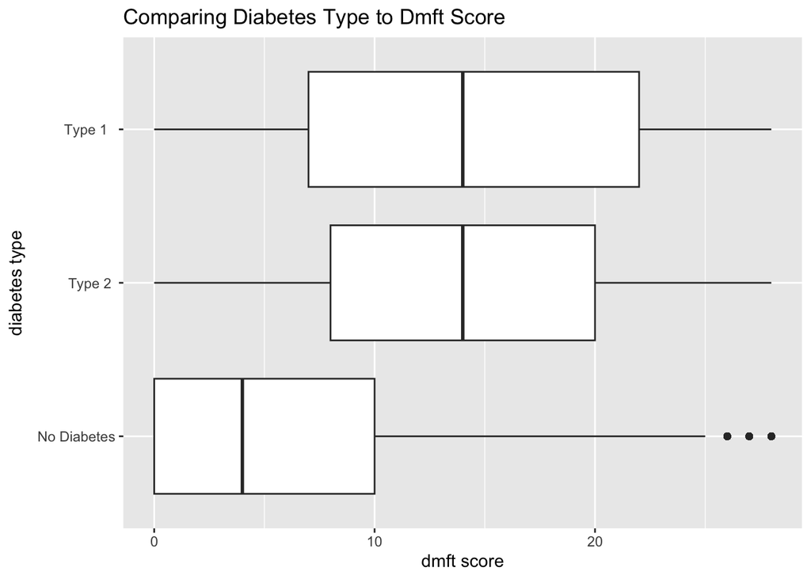

```r
nhanes.data <- nhanes.data %>%
  dplyr::filter(grepl("Type",diabetes_type) | grepl("Diabetes",diabetes_type)) #I am having so much trouble getting NA not to appear I don't know why

ggplot(data = nhanes.data, aes(dmft2, diabetes_type)) +
    geom_boxplot() +
    ggtitle("Comparing Diabetes Type to Dmft Score") +
    labs(y= "diabetes type", x = "dmft score")
```

At a first glance, it seems that there may be an association. With both types of diabetes leading to a higher dmft score.

## Regressions of dmft score

```r
summary((lm(dmft2 ~ diabetes_type, data = nhanes.data)))
```

```
##
## Call:
## lm(formula = dmft2 ~ diabetes_type, data = nhanes.data)
##
## Residuals:
##     Min      1Q  Median      3Q     Max
## -14.458  -6.464  -2.464   4.536  21.536
##
## Coefficients:
##                       Estimate Std. Error t value Pr(>|t|)
## (Intercept)            6.46410    0.03442  187.82   <2e-16 ***
## diabetes_type Type 2   7.99387    0.14165   56.43   <2e-16 ***
## diabetes_typeType 1    7.91473    0.35705   22.17   <2e-16 ***
## ---
## Signif. codes:  0 '***' 0.001 '**' 0.01 '*' 0.05 '.' 0.1 ' ' 1
##
## Residual standard error: 7.327 on 48581 degrees of freedom
##   (38362 observations deleted due to missingness)
## Multiple R-squared:  0.06934,    Adjusted R-squared:  0.0693
## F-statistic:  1810 on 2 and 48581 DF,  p-value: < 2.2e-16
```

```r
 #regression for just difference between type 1 and type 2, excluding those who don't have diabetes.
nhanes.diabetes <- nhanes.data %>%
  dplyr::filter(diabetes_type != "  No Diabetes")
summary((lm(dmft2 ~ diabetes_type, data = nhanes.diabetes)))
```

```
##
## Call:
## lm(formula = dmft2 ~ diabetes_type, data = nhanes.diabetes)
##
## Residuals:
##     Min      1Q  Median      3Q     Max
## -14.458  -6.458  -0.458   6.542  13.621
##
## Coefficients:
##                       Estimate Std. Error t value Pr(>|t|)
## (Intercept)           14.45797    0.15632  92.492   <2e-16 ***
## diabetes_typeType 1   -0.07914    0.43346  -0.183    0.855
## ---
## Signif. codes:  0 '***' 0.001 '**' 0.01 '*' 0.05 '.' 0.1 ' ' 1
##
## Residual standard error: 8.335 on 3266 degrees of freedom
##   (2682 observations deleted due to missingness)
## Multiple R-squared:  1.021e-05,  Adjusted R-squared:  -0.000296
## F-statistic: 0.03334 on 1 and 3266 DF,  p-value: 0.8551
```

It seems that diabetes in general, type 1 and type 2 are statistically significant when compared to the dmft score of those without diabetes. However, the difference between diabetes type 1 and type 2 are not statistically significant.

## Judging dental health through questionnaire data

Here I compare diabetes type to other factors of proxies of dental health: gum disease, tooth is loose, lost bone in mouth, and answer to the question of does dental pain create difficulty going about daily life? Overall, these should give a picture of dental health for the patients and how it impacts their lives. For each variable, I included a bar plot that considered counts of each dental health response when patients were grouped by diabetes type. However, due to many more patients reporting that they did not have diabetes, the graph is much better interpretable by the table below.

### Gum disease

Answers the question if the patient had ever been diagnosed with gum disease.

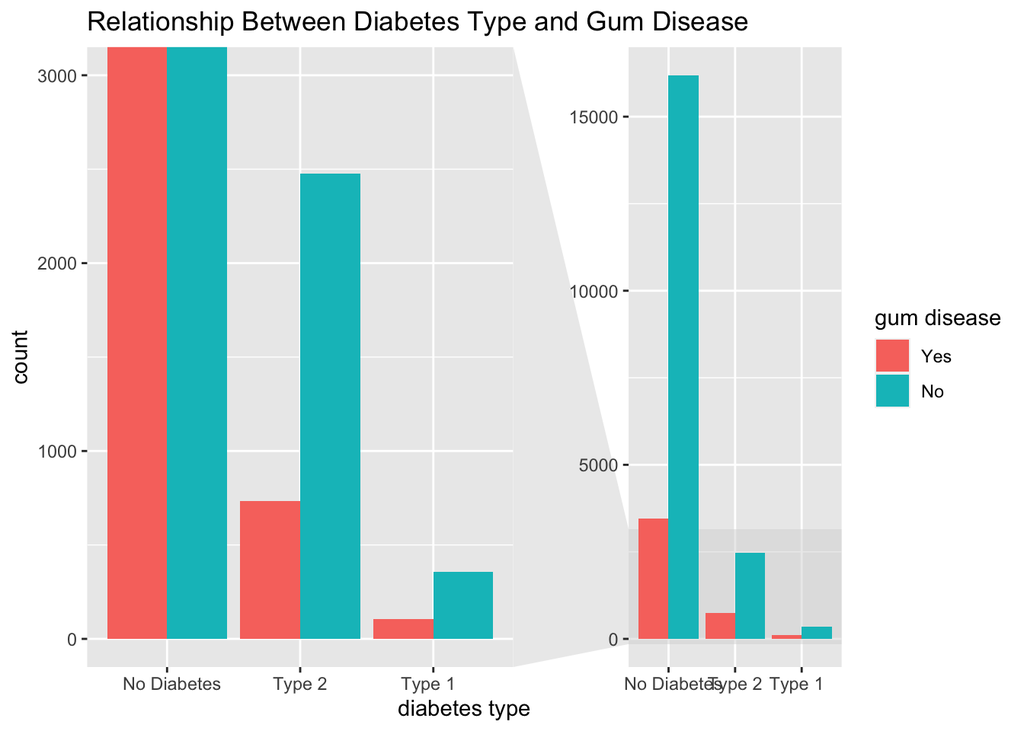

```r
knit_print.data.frame <- lemon_print

nhanes.gumdisease <- nhanes.data %>%
   filter(gum_disease != "NA" & gum_disease != "Refused" & gum_disease != "Don't know")

nhanes.data.gumdisease <- nhanes.data %>%
  group_by(diabetes_type, gum_disease) %>%
  filter(gum_disease != "NA" & gum_disease != "Refused" & gum_disease != "Don't know") %>%
  summarise(n = n()) %>%
  mutate(percent_per_factor = n/sum(n) * 100) %>%
  select(percent_per_factor, diabetes_type, gum_disease)

ggplot(data = nhanes.gumdisease, aes(x = factor(diabetes_type),
                          y = stat(count),
                          fill = factor(gum_disease))) +
    geom_bar(position = "dodge") +
    facet_zoom(ylim = c(0, 3000)) +
    labs(x = 'diabetes type', y = 'count', fill = 'gum disease') +
    ggtitle("Relationship Between Diabetes Type and Gum Disease")
```

```r
knitr::kable(nhanes.data.gumdisease, col.names = c("Percent  ",
                           "Diabetes type   ", "   Gum Disease"), align = "lll")
```

| Percent | Diabetes type | Gum Disease |
| --- | --- | --- |
| 17.59226 | No Diabetes | Yes |
| 82.40774 | No Diabetes | No |
| 22.87582 | Type 2 | Yes |
| 77.12418 | Type 2 | No |
| 23.01075 | Type 1 | Yes |
| 76.98925 | Type 1 | No |

The table indicates that gum disease seems more likely for patients with either type 1 or type 2 diabetes. A regression model was applied to check for significance.

```r
summary(glm(gum_disease ~ diabetes_type, data = nhanes.data, family = binomial(logit)))
```

```
##
## Call:
## glm(formula = gum_disease ~ diabetes_type, family = binomial(logit),
##     data = nhanes.data)
##
## Deviance Residuals:
##     Min       1Q   Median       3Q      Max
## -1.8727   0.6167   0.6167   0.6167   0.7162
##
## Coefficients:
##                       Estimate Std. Error z value Pr(>|z|)
## (Intercept)            1.56343    0.01871  83.575  < 2e-16 ***
## diabetes_type Type 2  -0.32812    0.04589  -7.150 8.69e-13 ***
## diabetes_typeType 1   -0.33363    0.11148  -2.993  0.00277 **
## ---
## Signif. codes:  0 '***' 0.001 '**' 0.01 '*' 0.05 '.' 0.1 ' ' 1
##
## (Dispersion parameter for binomial family taken to be 1)
##
##     Null deviance: 22439  on 23694  degrees of freedom
## Residual deviance: 22384  on 23692  degrees of freedom
##   (63251 observations deleted due to missingness)
## AIC: 22390
##
## Number of Fisher Scoring iterations: 4
```

```r
summary(glm(gum_disease ~ diabetes_type, data = nhanes.diabetes, family = binomial(logit)))
```

```
##
## Call:
## glm(formula = gum_disease ~ diabetes_type, family = binomial(logit),
##     data = nhanes.diabetes)
##
## Deviance Residuals:
##     Min       1Q   Median       3Q      Max
## -1.7266   0.7145   0.7145   0.7145   0.7162
##
## Coefficients:
##                        Estimate Std. Error z value Pr(>|z|)
## (Intercept)            1.235313   0.041906  29.478   <2e-16 ***
## diabetes_typeType 1   -0.005509   0.117619  -0.047    0.963
## ---
## Signif. codes:  0 '***' 0.001 '**' 0.01 '*' 0.05 '.' 0.1 ' ' 1
##
## (Dispersion parameter for binomial family taken to be 1)
##
##     Null deviance: 3987.3  on 3735  degrees of freedom
## Residual deviance: 3987.3  on 3734  degrees of freedom
##   (2214 observations deleted due to missingness)
## AIC: 3991.3
##
## Number of Fisher Scoring iterations: 4
```

Once again, both type 1 and type 2 diabetes were statistically significant against people who didn’t have diabetes. However, the difference between type 1 and type 2 is not significant.

### Loose tooth

Answers the question if the patient ever felt they had a loose permanent tooth, an indicator of poor dental health.

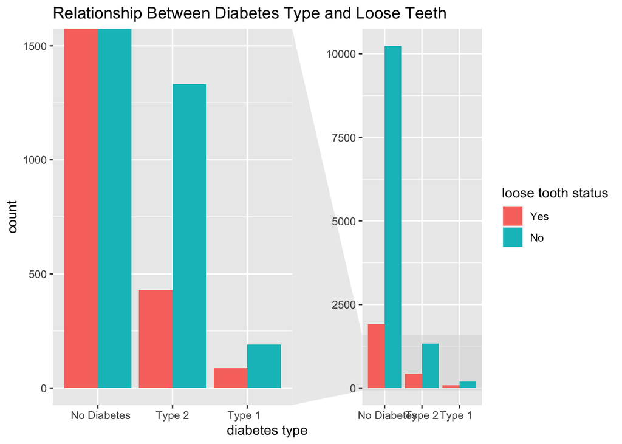

```r
nhanes.loose.tooth <- nhanes.data %>%
  filter(tooth_loose != "NA" & tooth_loose != "Refused" & tooth_loose != "Don't know")
ggplot(data = nhanes.loose.tooth, aes(x = factor(diabetes_type),
                          y = stat(count),
                          fill = factor(tooth_loose))) +
    geom_bar(position = "dodge") +
    facet_zoom(ylim = c(0, 1500)) +
    labs(x = 'diabetes type', y = 'count', fill = 'loose tooth status') +
    ggtitle("Relationship Between Diabetes Type and Loose Teeth")
```

```r
nhanes.data.loose.tooth <- nhanes.loose.tooth %>%
  group_by(diabetes_type, tooth_loose) %>%
  summarise(n = n()) %>%
  mutate(percent_per_factor = n/sum(n) * 100)%>%
  select(percent_per_factor, diabetes_type, tooth_loose)

knitr::kable(nhanes.data.loose.tooth, col.names = c("Percent  ",
                           "Diabetes type   ", "   Loose tooth?"), align = "lll")
```

| Percent | Diabetes type | Loose tooth? |
| --- | --- | --- |
| 15.69418 | No Diabetes | Yes |
| 84.30582 | No Diabetes | No |
| 24.37500 | Type 2 | Yes |
| 75.62500 | Type 2 | No |
| 31.65468 | Type 1 | Yes |
| 68.34532 | Type 1 | No |

```r
summary(glm(tooth_loose ~ diabetes_type, data = nhanes.data, family = binomial(logit)))
```

```
##
## Call:
## glm(formula = tooth_loose ~ diabetes_type, family = binomial(logit),
##     data = nhanes.data)
##
## Deviance Residuals:
##     Min       1Q   Median       3Q      Max
## -1.9252   0.5839   0.5839   0.5839   0.8668
##
## Coefficients:
##                       Estimate Std. Error z value Pr(>|z|)
## (Intercept)            1.68282    0.02494  67.484  < 2e-16 ***
## diabetes_type Type 2  -0.54834    0.06085  -9.012  < 2e-16 ***
## diabetes_typeType 1   -0.89747    0.13102  -6.850  7.4e-12 ***
## ---
## Signif. codes:  0 '***' 0.001 '**' 0.01 '*' 0.05 '.' 0.1 ' ' 1
##
## (Dispersion parameter for binomial family taken to be 1)
##
##     Null deviance: 12983  on 14211  degrees of freedom
## Residual deviance: 12872  on 14209  degrees of freedom
##   (72734 observations deleted due to missingness)
## AIC: 12878
##
## Number of Fisher Scoring iterations: 4
```

```r
summary(glm(tooth_loose ~ diabetes_type, data = nhanes.diabetes, family = binomial(logit)))
```

```
##
## Call:
## glm(formula = tooth_loose ~ diabetes_type, family = binomial(logit),
##     data = nhanes.diabetes)
##
## Deviance Residuals:
##     Min       1Q   Median       3Q      Max
## -1.6813  -1.5238   0.7468   0.7468   0.8668
##
## Coefficients:
##                       Estimate Std. Error z value Pr(>|z|)
## (Intercept)             1.1345     0.0555  20.440   <2e-16 ***
## diabetes_typeType 1    -0.3491     0.1401  -2.492   0.0127 *
## ---
## Signif. codes:  0 '***' 0.001 '**' 0.01 '*' 0.05 '.' 0.1 ' ' 1
##
## (Dispersion parameter for binomial family taken to be 1)
##
##     Null deviance: 2311.9  on 2043  degrees of freedom
## Residual deviance: 2305.9  on 2042  degrees of freedom
##   (3906 observations deleted due to missingness)
## AIC: 2309.9
##
## Number of Fisher Scoring iterations: 4
```

### Lost bone

Did a doctor tell the patient that they had lost bone around their teeth?

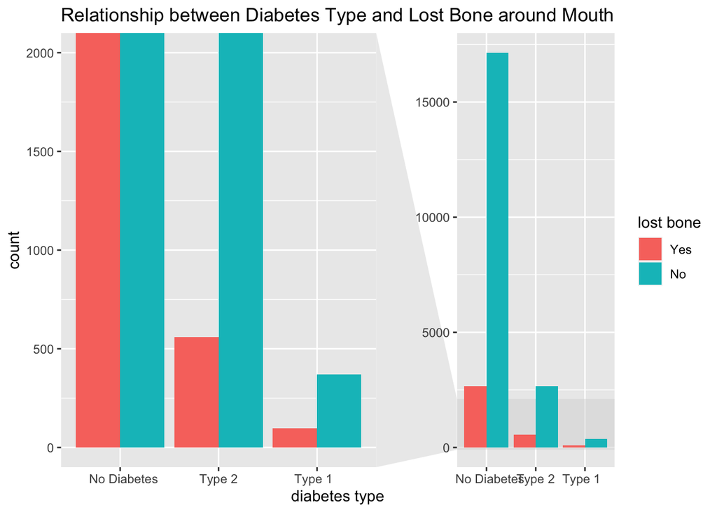

```r
nhanes.lost.bone <- nhanes.data %>%
  filter(lost_bone != "NA" & lost_bone != "Refused" & lost_bone != "Don't know")
ggplot(data = nhanes.lost.bone, aes(x = factor(diabetes_type),
                          y = stat(count),
                          fill = factor(lost_bone))) +
    geom_bar(position = "dodge") +
    facet_zoom(ylim = c(0, 2000)) +
    labs(x = 'diabetes type', y = 'count', fill = 'lost bone') +
    ggtitle("Relationship between Diabetes Type and Lost Bone around Mouth")
```

```r
nhanes.data.lost.bone <- nhanes.lost.bone %>%
  group_by(diabetes_type, lost_bone) %>%
  summarise(n = n()) %>%
  mutate(percent_per_factor = n/sum(n) * 100) %>%
  select(percent_per_factor, diabetes_type, lost_bone)

knitr::kable(nhanes.data.lost.bone, col.names = c("Percent  ",
                           "Diabetes type   ", "   Lost bone"), align = "lll")
```

| Percent | Diabetes type | Lost bone |
| --- | --- | --- |
| 13.45115 | No Diabetes | Yes |
| 86.54885 | No Diabetes | No |
| 17.33210 | Type 2 | Yes |
| 82.66790 | Type 2 | No |
| 20.72650 | Type 1 | Yes |
| 79.27350 | Type 1 | No |

```r
summary(glm(lost_bone ~ diabetes_type, data = nhanes.data, family = binomial(logit)))
```

```
##
## Call:
## glm(formula = lost_bone ~ diabetes_type, family = binomial(logit),
##     data = nhanes.data)
##
## Deviance Residuals:
##     Min       1Q   Median       3Q      Max
## -2.0069   0.5353   0.5353   0.5353   0.6775
##
## Coefficients:
##                       Estimate Std. Error z value Pr(>|z|)
## (Intercept)            1.87059    0.02081  89.875  < 2e-16 ***
## diabetes_type Type 2  -0.29641    0.05088  -5.826 5.69e-09 ***
## diabetes_typeType 1   -0.51571    0.11577  -4.455 8.40e-06 ***
## ---
## Signif. codes:  0 '***' 0.001 '**' 0.01 '*' 0.05 '.' 0.1 ' ' 1
##
## (Dispersion parameter for binomial family taken to be 1)
##
##     Null deviance: 19205  on 23694  degrees of freedom
## Residual deviance: 19157  on 23692  degrees of freedom
##   (63251 observations deleted due to missingness)
## AIC: 19163
##
## Number of Fisher Scoring iterations: 4
```

```r
summary(glm(lost_bone ~ diabetes_type, data = nhanes.diabetes, family = binomial(logit)))
```

```
##
## Call:
## glm(formula = lost_bone ~ diabetes_type, family = binomial(logit),
##     data = nhanes.diabetes)
##
## Deviance Residuals:
##     Min       1Q   Median       3Q      Max
## -1.8775   0.6137   0.6137   0.6137   0.6775
##
## Coefficients:
##                       Estimate Std. Error z value Pr(>|z|)
## (Intercept)            1.57418    0.04643  33.905   <2e-16 ***
## diabetes_typeType 1   -0.21930    0.12298  -1.783   0.0746 .
## ---
## Signif. codes:  0 '***' 0.001 '**' 0.01 '*' 0.05 '.' 0.1 ' ' 1
##
## (Dispersion parameter for binomial family taken to be 1)
##
##     Null deviance: 3474.9  on 3735  degrees of freedom
## Residual deviance: 3471.8  on 3734  degrees of freedom
##   (2214 observations deleted due to missingness)
## AIC: 3475.8
##
## Number of Fisher Scoring iterations: 4
```

Both type 1 and type 2 diabetes were statistically significant against people who didn’t have diabetes. Here type 1 diabetes is close to significant compared to diabetes type 2, but not quite.

### Tooth difficulty

Did they ever have difficulty completing daily tasks due to dental pain?

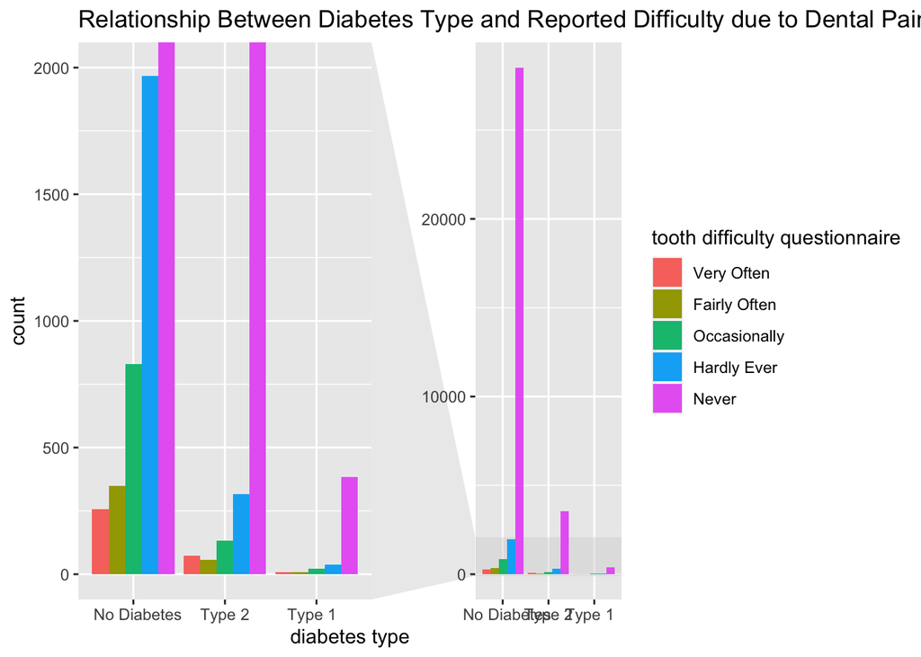

```r
nhanes.tooth.difficulty <- nhanes.data %>%
  dplyr::filter(difficulty_bc_teeth != "NA" & difficulty_bc_teeth != "Refused" & difficulty_bc_teeth != "Don't know")

ggplot(data = nhanes.tooth.difficulty, aes(x = factor(diabetes_type),
                          y = stat(count),
                          fill = factor(difficulty_bc_teeth))) +
    geom_bar(position = "dodge") +
    facet_zoom(ylim = c(0, 2000)) +
    labs(x = 'diabetes type', y = 'count', fill = 'tooth difficulty questionnaire') +
    ggtitle("Relationship Between Diabetes Type and Reported Difficulty due to Dental Pain")
```

```r
nhanes.data.difficulty <- nhanes.data %>%
  group_by(diabetes_type, difficulty_bc_teeth) %>%
  filter(difficulty_bc_teeth != "NA" & difficulty_bc_teeth != "Refused" & difficulty_bc_teeth != "Don't know") %>%
  summarise(n = n()) %>%
  mutate(percent_per_factor = n/sum(n) * 100) %>%
  select(percent_per_factor, diabetes_type, difficulty_bc_teeth)

knitr::kable(nhanes.data.difficulty, col.names = c("Percent  ",
                           "Diabetes type   ", "   Difficulty"), align = "lll")
```

| Percent | Diabetes type | Difficulty |
| --- | --- | --- |
| 0.8083466 | No Diabetes | Very Often |
| 1.0934612 | No Diabetes | Fairly Often |
| 2.5973619 | No Diabetes | Occasionally |
| 6.1597268 | No Diabetes | Hardly Ever |
| 89.3411035 | No Diabetes | Never |
| 1.7796197 | Type 2 | Very Often |
| 1.3651877 | Type 2 | Fairly Often |
| 3.2179425 | Type 2 | Occasionally |
| 7.6791809 | Type 2 | Hardly Ever |
| 85.9580692 | Type 2 | Never |
| 1.7429194 | Type 1 | Very Often |
| 1.5250545 | Type 1 | Fairly Often |
| 4.5751634 | Type 1 | Occasionally |
| 8.2788671 | Type 1 | Hardly Ever |
| 83.8779956 | Type 1 | Never |

```r
summary(glm(difficulty_bc_teeth ~ diabetes_type, data = nhanes.data, family = binomial(logit)))
```

```
##
## Call:
## glm(formula = difficulty_bc_teeth ~ diabetes_type, family = binomial(logit),
##     data = nhanes.data)
##
## Deviance Residuals:
##     Min       1Q   Median       3Q      Max
## -3.1045   0.1273   0.1273   0.1273   0.1894
##
## Coefficients:
##                       Estimate Std. Error z value Pr(>|z|)
## (Intercept)            4.81077    0.06251  76.963  < 2e-16 ***
## diabetes_type Type 2  -0.79871    0.13362  -5.978 2.26e-09 ***
## diabetes_typeType 1   -0.77874    0.36211  -2.151   0.0315 *
## ---
## Signif. codes:  0 '***' 0.001 '**' 0.01 '*' 0.05 '.' 0.1 ' ' 1
##
## (Dispersion parameter for binomial family taken to be 1)
##
##     Null deviance: 3847.5  on 36512  degrees of freedom
## Residual deviance: 3814.2  on 36510  degrees of freedom
##   (50433 observations deleted due to missingness)
## AIC: 3820.2
##
## Number of Fisher Scoring iterations: 7
```

```r
summary(glm(difficulty_bc_teeth ~ diabetes_type, data = nhanes.diabetes, family = binomial(logit)))
```

```
##
## Call:
## glm(formula = difficulty_bc_teeth ~ diabetes_type, family = binomial(logit),
##     data = nhanes.diabetes)
##
## Deviance Residuals:
##     Min       1Q   Median       3Q      Max
## -2.8459   0.1894   0.1894   0.1894   0.1894
##
## Coefficients:
##                       Estimate Std. Error z value Pr(>|z|)
## (Intercept)            4.01205    0.11808  33.978   <2e-16 ***
## diabetes_typeType 1    0.01997    0.37566   0.053    0.958
## ---
## Signif. codes:  0 '***' 0.001 '**' 0.01 '*' 0.05 '.' 0.1 ' ' 1
##
## (Dispersion parameter for binomial family taken to be 1)
##
##     Null deviance: 813.73  on 4565  degrees of freedom
## Residual deviance: 813.73  on 4564  degrees of freedom
##   (1384 observations deleted due to missingness)
## AIC: 817.73
##
## Number of Fisher Scoring iterations: 6
```

Diabetes status is significant compared to non-diabetes status, but not type 1 vs type 2.

## Examining possible co-variates

### Cigarette smoking

Here cigarette smoking is examined as a possible co-variate. Tobacco from cigarettes in a well established mechanism for poor dental health. I used the answer to the question “Have you smoked 100 cigarettes” as a proxy for smoking because this would include people who had smoked and quit as well as current smokers. I looked at the proportion of respondents answering yes to smoking and saw that a greater percentage of diabetes patients do smoke. This confirmed my reasoning for adjusting for this variable. I also ensured that the dmft score would indicate a statistically significant relationship between smoking status and dmft score. This also works to confirm my methedology for the diabetes type compared to dmft score because there is already an established relationship for smoking.

```r
cigarette.counts <- nhanes.data %>%
  dplyr::filter(hundred_cigs != "refused" & hundred_cigs != "don't know") %>%
  group_by(diabetes_type) %>%
  count(hundred_cigs)
knitr::kable(cigarette.counts)
```

| diabetes_type | hundred_cigs | n |
| --- | --- | --- |
| No Diabetes | yes | 19738 |
| No Diabetes | no | 25118 |
| Type 2 | yes | 2582 |
| Type 2 | no | 2610 |
| Type 1 | yes | 330 |
| Type 1 | no | 326 |

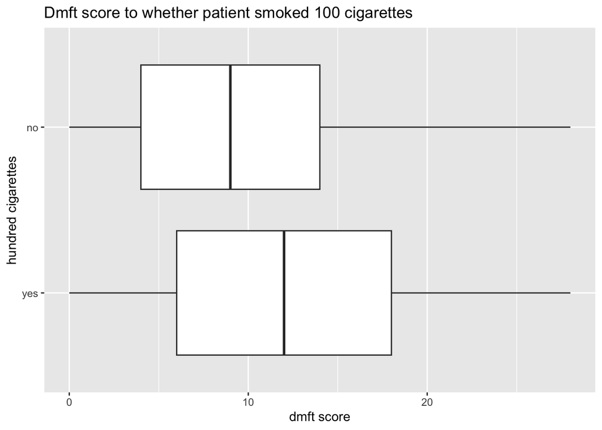

```r
nhanes.hundred.cigs <- nhanes.data %>%
  dplyr::filter(hundred_cigs == "yes" | hundred_cigs == "no")
ggplot(data = nhanes.hundred.cigs, aes(dmft2, hundred_cigs)) +
    geom_boxplot() +
    ggtitle("Dmft score to whether patient smoked 100 cigarettes") +
    labs(y= "hundred cigarettes", x = "dmft score")
```

```r
summary((lm(dmft2 ~ hundred_cigs, data = nhanes.hundred.cigs)))
```

```
##
## Call:
## lm(formula = dmft2 ~ hundred_cigs, data = nhanes.hundred.cigs)
##
## Residuals:
##      Min       1Q   Median       3Q      Max
## -12.4866  -6.4866  -0.6594   5.3406  18.3406
##
## Coefficients:
##                Estimate Std. Error t value Pr(>|t|)
## (Intercept)    12.48661    0.07143  174.80   <2e-16 ***
## hundred_cigsno -2.82722    0.09419  -30.02   <2e-16 ***
## ---
## Signif. codes:  0 '***' 0.001 '**' 0.01 '*' 0.05 '.' 0.1 ' ' 1
##
## Residual standard error: 7.699 on 27340 degrees of freedom
##   (23362 observations deleted due to missingness)
## Multiple R-squared:  0.0319, Adjusted R-squared:  0.03187
## F-statistic: 900.9 on 1 and 27340 DF,  p-value: < 2.2e-16
```

Regression was significant for smoking relation to worse dmft score. I then decided to redo the previous dmft score with diabetes type, but this time exclude those who reported yes for smoking one hundred cigarettes.

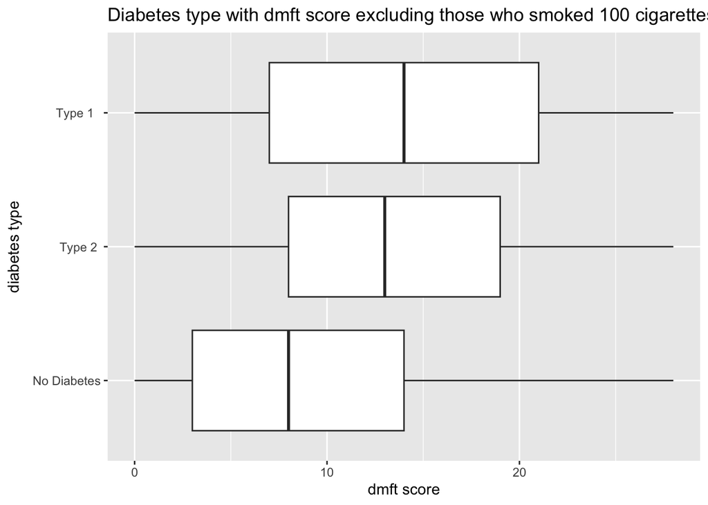

```r
nhanes.no.smoking <- nhanes.data%>%
  dplyr::filter(hundred_cigs != "yes")
ggplot(data = nhanes.no.smoking, aes(dmft2, diabetes_type)) +
    geom_boxplot() +
    ggtitle("Diabetes type with dmft score excluding those who smoked 100 cigarettes")+
    labs(y= "diabetes type", x = "dmft score")
```

```r
summary((lm(dmft2 ~ diabetes_type, data = nhanes.no.smoking)))
```

```
##
## Call:
## lm(formula = dmft2 ~ diabetes_type, data = nhanes.no.smoking)
##
## Residuals:
##     Min      1Q  Median      3Q     Max
## -14.174  -6.215  -1.216   4.785  18.785
##
## Coefficients:
##                       Estimate Std. Error t value Pr(>|t|)
## (Intercept)            9.21552    0.06049 152.353   <2e-16 ***
## diabetes_type Type 2   4.30383    0.20006  21.512   <2e-16 ***
## diabetes_typeType 1    4.95861    0.51064   9.711   <2e-16 ***
## ---
## Signif. codes:  0 '***' 0.001 '**' 0.01 '*' 0.05 '.' 0.1 ' ' 1
##
## Residual standard error: 7.189 on 15743 degrees of freedom
##   (12354 observations deleted due to missingness)
## Multiple R-squared:  0.03333,    Adjusted R-squared:  0.03321
## F-statistic: 271.4 on 2 and 15743 DF,  p-value: < 2.2e-16
```

I found that the data was still statistically significant and diabetes type 1 and 2 were higher than patients without diabetes. I then compared the effectiveness of regression models when considering hundred cigarettes smoking status as a co-variate. The three regressions below refer to clm1 = significance of diabetes type alone, clm 2 = significance of diabetes type and one hundred cigarettes, clm 3 = significance of diabetes type and one hundred cigarettes but the people who both smoke one hundred cigarettes and have diabetes are not overly weighted the way that they are in clm 2. In this way clm 2 allows for the intercept of the regression to change for a better fit, and clm 3 allows for the slope of the regression to also change for a better fit.

```r
clm1 <- lm(dmft2 ~ diabetes_type, data = nhanes.data)
clm2 <- lm(dmft2 ~ diabetes_type + hundred_cigs, data = nhanes.data)
clm3 <- lm(dmft2 ~ diabetes_type + hundred_cigs + hundred_cigs:diabetes_type, data = nhanes.data)

modelsummary(list(clm1, clm2, clm3), coef_omit = "Intercept",
             statistic = c("p = {p.value}"),
             estimate = "{estimate} [{conf.low}, {conf.high}]")
```

|  | Model 1 | Model 2 | Model 3 |
| --- | --- | --- | --- |
| diabetes_type Type 2 | 7.994 [7.716, 8.272] | 4.032 [3.735, 4.328] | 3.739 [3.313, 4.164] |
|  | p = <0.001 | p = <0.001 | p = <0.001 |
| diabetes_typeType 1 | 7.915 [7.215, 8.615] | 4.980 [4.222, 5.738] | 4.984 [3.896, 6.073] |
|  | p = <0.001 | p = <0.001 | p = <0.001 |
| hundred_cigsno |  | −2.691 [−2.873, −2.509] | −2.750 [−2.944, −2.556] |
|  |  | p = <0.001 | p = <0.001 |
| hundred_cigsrefused |  | 8.827 [1.394, 16.260] | 8.792 [1.359, 16.225] |
|  |  | p = 0.020 | p = 0.020 |
| hundred_cigsdon’t know |  | 2.134 [−1.473, 5.742] | 1.480 [−2.239, 5.198] |
|  |  | p = 0.246 | p = 0.435 |
| diabetes_type Type 2 × hundred_cigsno |  |  | 0.563 [−0.030, 1.156] |
|  |  |  | p = 0.063 |
| diabetes_typeType 1 × hundred_cigsno |  |  | −0.018 [−1.534, 1.499] |
|  |  |  | p = 0.982 |
| diabetes_type Type 2 × hundred_cigsdon’t know |  |  | 10.824 [−4.502, 26.150] |
|  |  |  | p = 0.166 |
| Num.Obs. | 48584 | 27363 | 27363 |
| R2 | 0.069 | 0.061 | 0.062 |
| R2 Adj. | 0.069 | 0.061 | 0.061 |
| AIC | 331390.9 | 188531.8 | 188532.5 |
| BIC | 331426.0 | 188589.3 | 188614.7 |
| Log.Lik. | −165691.430 | −94258.903 | −94256.260 |
| RMSE | 7.33 | 7.58 | 7.58 |

It seems that both the original model and new one with the hundred cigarettes as a co-variate were equally effective. Model 3 is worse, indicating that cigarette smoking should not be considered as a co-variate and allowing it to change the slope, reduces the efficacy of the model.

### Food Security

I decided to also look into the variable of food security. Type 2 diabetes can be very related to malnutrition and food intake. Additionally, types of food and malnutrition can impact dental health (6). I considered that there malnutrition could thus be a co-variate. To study malnutrition, I looked at the adult food security a factor with 4 categories: full, marginal, low, and very low.

I first looked at an overview of the data and a breakdown of who experienced food insecurity with regard to race, sex, age, and diabetes type in order to learn more about who experienced food insecurity.

```r
nhanes.data %>%
  dplyr::select(c(age, sex, race, adult_food_security)) %>%
  tbl_summary(by = adult_food_security,
    statistic = list(all_continuous() ~ "{mean} ({sd})",
              all_categorical() ~ "{n} / {N} ({p}%)"),
              digits = all_continuous() ~ 2,
              missing_text = "(Missing)") %>%
  add_overall() %>%
  modify_header(label ~ "**Variable**") %>%
  modify_caption("**Patient Characteristics Grouped By Adult Food Security**") %>%
  bold_labels()
```

**Patient Characteristics Grouped By Adult Food Security**

| **Variable** | **Overall**, N = 74,742<sup>1</sup> | **full**, N = 49,710<sup>1</sup> | **marginal**, N = 9,916<sup>1</sup> | **low**, N = 9,102<sup>1</sup> | **very low**, N = 6,014<sup>1</sup> |
| --- | --- | --- | --- | --- | --- |
| age | 32.84 (24.53) | 35.32 (25.29) | 27.60 (22.50) | 27.92 (22.23) | 28.48 (21.37) |
| sex |  |  |  |  |  |
| men | 36,861 / 74,742 (49%) | 24,705 / 49,710 (50%) | 4,759 / 9,916 (48%) | 4,407 / 9,102 (48%) | 2,990 / 6,014 (50%) |
| women | 37,881 / 74,742 (51%) | 25,005 / 49,710 (50%) | 5,157 / 9,916 (52%) | 4,695 / 9,102 (52%) | 3,024 / 6,014 (50%) |
| race |  |  |  |  |  |
| White | 27,677 / 74,742 (37%) | 21,531 / 49,710 (43%) | 2,342 / 9,916 (24%) | 1,966 / 9,102 (22%) | 1,838 / 6,014 (31%) |
| MexicanAmerican | 14,802 / 74,742 (20%) | 7,863 / 49,710 (16%) | 2,668 / 9,916 (27%) | 2,960 / 9,102 (33%) | 1,311 / 6,014 (22%) |
| Hispanic | 6,609 / 74,742 (8.8%) | 3,630 / 49,710 (7.3%) | 1,091 / 9,916 (11%) | 1,165 / 9,102 (13%) | 723 / 6,014 (12%) |
| Black | 17,582 / 74,742 (24%) | 10,643 / 49,710 (21%) | 2,926 / 9,916 (30%) | 2,334 / 9,102 (26%) | 1,679 / 6,014 (28%) |
| Other | 8,072 / 74,742 (11%) | 6,043 / 49,710 (12%) | 889 / 9,916 (9.0%) | 677 / 9,102 (7.4%) | 463 / 6,014 (7.7%) |

<sup>1</sup> Mean (SD); n / N (%)

```r
nhanes.data %>%
  dplyr::select(c(diabetes_type, adult_food_security)) %>%
  tbl_summary(by = diabetes_type,
    statistic = list(all_continuous() ~ "{mean} ({sd})",
              all_categorical() ~ "{n} / {N} ({p}%)"),
              digits = all_continuous() ~ 2,
              missing_text = "(Missing)") %>%
  add_overall() %>%
  modify_header(label ~ "**Variable**") %>%
  modify_caption("**Food Security Categorized by Diabetes Type**") %>%
  bold_labels()
```

**Food Security Categorized by Diabetes Type**

| **Variable** | **Overall**, N = 86,946<sup>1</sup> | ** No Diabetes**, N = 80,996<sup>1</sup> | ** Type 2 **, N = 5,249<sup>1</sup> | **NA NA **, N = 0<sup>1</sup> | **Type 1 **, N = 701<sup>1</sup> |
| --- | --- | --- | --- | --- | --- |
| adult_food_security |  |  |  |  |  |
| full | 49,710 / 74,742 (67%) | 46,232 / 69,464 (67%) | 3,129 / 4,682 (67%) | 0 / 0 (NA%) | 349 / 596 (59%) |
| marginal | 9,916 / 74,742 (13%) | 9,264 / 69,464 (13%) | 564 / 4,682 (12%) | 0 / 0 (NA%) | 88 / 596 (15%) |
| low | 9,102 / 74,742 (12%) | 8,432 / 69,464 (12%) | 583 / 4,682 (12%) | 0 / 0 (NA%) | 87 / 596 (15%) |
| very low | 6,014 / 74,742 (8.0%) | 5,536 / 69,464 (8.0%) | 406 / 4,682 (8.7%) | 0 / 0 (NA%) | 72 / 596 (12%) |
| (Missing) | 12,204 | 11,532 | 567 | 0 | 105 |

<sup>1</sup> n / N (%)

It is not immediately clear if one group experiences food insecurity more than another. I decided to create a box plot where I considered food insecurity on a 1-4 numeric scale. Even though adult food insecurity was not a continuous variable, I treated it as such because the math would still work to consider higher averages indicating a more overall food insecure population. In this way, it was more easily visualized.

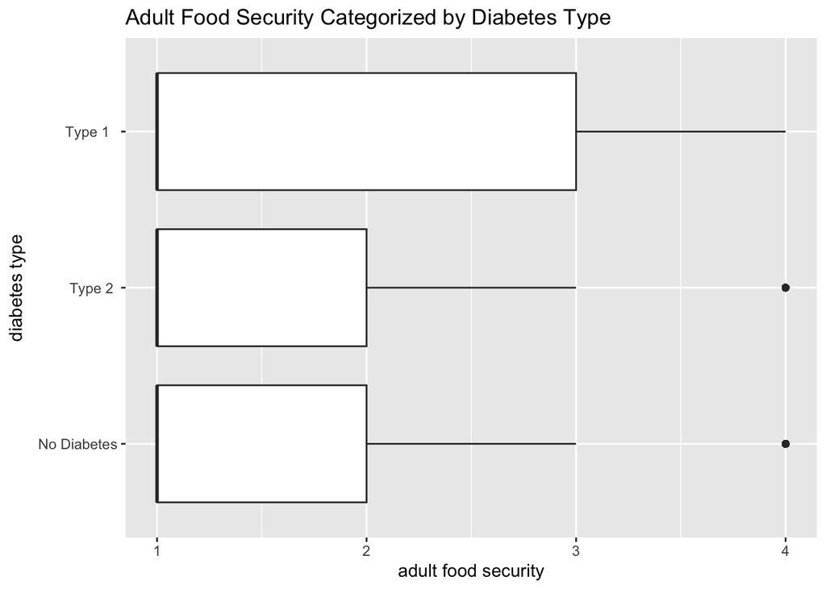

```r
nhanes.food.security <- nhanes.data %>%
  dplyr::filter(adult_food_security != "NA")

ggplot(data = nhanes.food.security, aes(as.numeric(adult_food_security), diabetes_type)) +
    geom_boxplot() +
    ggtitle("Adult Food Security Categorized by Diabetes Type") +
    labs(y= "diabetes type", x = "adult food security")
```

```r
summary((lm(as.numeric(adult_food_security) ~ diabetes_type, data = nhanes.data)))
```

```
##
## Call:
## lm(formula = as.numeric(adult_food_security) ~ diabetes_type,
##     data = nhanes.data)
##
## Residuals:
##     Min      1Q  Median      3Q     Max
## -0.8020 -0.6152 -0.6152  0.3848  2.3848
##
## Coefficients:
##                       Estimate Std. Error t value Pr(>|t|)
## (Intercept)           1.615225   0.003722 433.978  < 2e-16 ***
## diabetes_type Type 2  0.014420   0.014811   0.974     0.33
## diabetes_typeType 1   0.186788   0.040353   4.629 3.68e-06 ***
## ---
## Signif. codes:  0 '***' 0.001 '**' 0.01 '*' 0.05 '.' 0.1 ' ' 1
##
## Residual standard error: 0.9809 on 74739 degrees of freedom
##   (12204 observations deleted due to missingness)
## Multiple R-squared:  0.0002966,  Adjusted R-squared:  0.0002699
## F-statistic: 11.09 on 2 and 74739 DF,  p-value: 1.531e-05
```

Here it actually seems like only people with type 1 diabetes experience more food insecurity. This does not fit into my assumptions about the relationship between food insecurity and type 2 diabetes, but could reveal interesting points about type 1 diabetes, an autoimmune disorder. It is also possible that due to the smaller data set for type 1 diabetes patients, this data has been shifted somewhat due to outliers that are over-represented.

I also looked at the relationship between dmft score and adult food security.

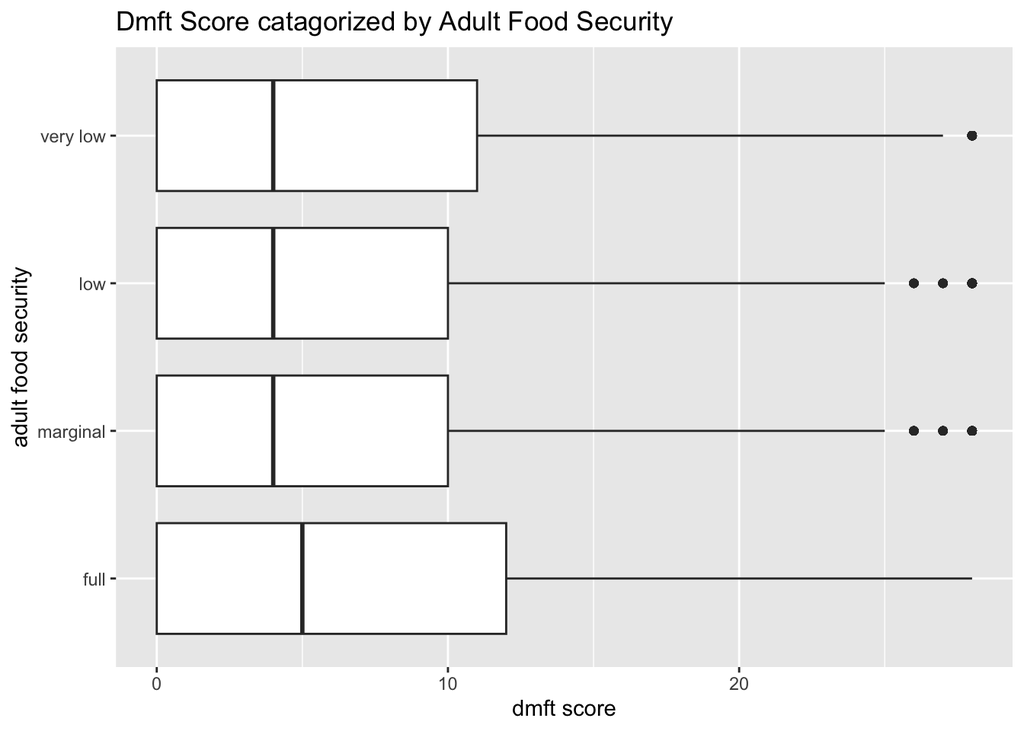

```r
ggplot(data = nhanes.food.security, aes(dmft2, adult_food_security)) +
    geom_boxplot()+
    ggtitle("Dmft Score catagorized by Adult Food Security")+
    labs(y= "adult food security", x = "dmft score")
```

```r
summary((lm(dmft2 ~ adult_food_security, data = nhanes.data)))
```

```
##
## Call:
## lm(formula = dmft2 ~ adult_food_security, data = nhanes.data)
##
## Residuals:
##    Min     1Q Median     3Q    Max
## -7.444 -6.444 -2.444  4.556 21.612
##
## Coefficients:
##                             Estimate Std. Error t value Pr(>|t|)
## (Intercept)                  7.44411    0.04834 154.000  < 2e-16 ***
## adult_food_securitymarginal -1.05628    0.11436  -9.236  < 2e-16 ***
## adult_food_securitylow      -0.61237    0.11820  -5.181 2.22e-07 ***
## adult_food_securityvery low -0.39972    0.13687  -2.920   0.0035 **
## ---
## Signif. codes:  0 '***' 0.001 '**' 0.01 '*' 0.05 '.' 0.1 ' ' 1
##
## Residual standard error: 7.712 on 39721 degrees of freedom
##   (47221 observations deleted due to missingness)
## Multiple R-squared:  0.002507,   Adjusted R-squared:  0.002431
## F-statistic: 33.27 on 3 and 39721 DF,  p-value: < 2.2e-16
```

Again there does not seem to be much of a difference between dmft score and food security. In fact, people with full food security seem to have a higher dmft score. I believe that once again, the data for marginal, low, and very low populations are improperly representative of dmft score because the portion of the data sets are too small to overcome the influence of outliers.

### Last dental visit

Finally, I chose to study the possible co-variate for the last time a patient went to the dentist. My prediction was that this would also play an important role in dental health, due to frequent access to dental care for better preventative care for teeth.

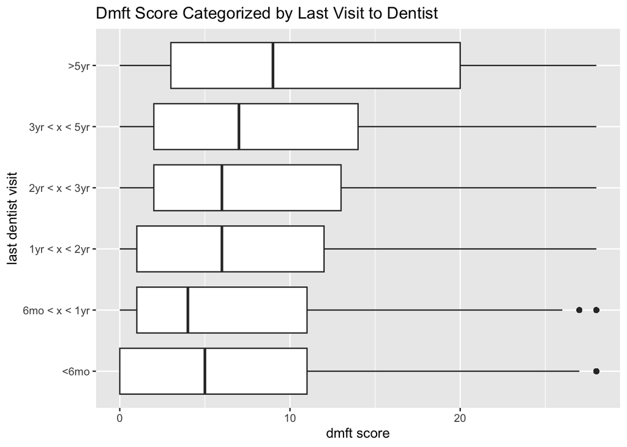

```r
nhanes.never <- nhanes.data %>%
  filter(last_dentist != "Never" & last_dentist != "NA" & last_dentist != "Don't know" & last_dentist != "Refused")

ggplot(data = nhanes.never, aes(dmft2, last_dentist)) +
    geom_boxplot() +
    ggtitle("Dmft Score Categorized by Last Visit to Dentist") +
    labs(y= "last dentist visit", x = "dmft score")
```

```r
summary((lm(dmft2 ~ last_dentist, data = nhanes.data)))
```

```
##
## Call:
## lm(formula = dmft2 ~ last_dentist, data = nhanes.data)
##
## Residuals:
##     Min      1Q  Median      3Q     Max
## -11.567  -6.567  -1.440   4.281  26.878
##
## Coefficients:
##                           Estimate Std. Error t value Pr(>|t|)
## (Intercept)                6.71921    0.04884 137.581  < 2e-16 ***
## last_dentist6mo < x < 1yr -0.09768    0.09517  -1.026    0.305
## last_dentist1yr < x < 2yr  0.84878    0.11130   7.626 2.46e-14 ***
## last_dentist2yr < x < 3yr  1.72105    0.14606  11.783  < 2e-16 ***
## last_dentist3yr < x < 5yr  2.35096    0.15510  15.158  < 2e-16 ***
## last_dentist>5yr           4.84820    0.12242  39.604  < 2e-16 ***
## last_dentistNever         -5.59707    0.12881 -43.451  < 2e-16 ***
## last_dentistRefused        3.78079    2.96716   1.274    0.203
## last_dentistDon't know    -0.52110    0.70753  -0.737    0.461
## ---
## Signif. codes:  0 '***' 0.001 '**' 0.01 '*' 0.05 '.' 0.1 ' ' 1
##
## Residual standard error: 7.267 on 48572 degrees of freedom
##   (38365 observations deleted due to missingness)
## Multiple R-squared:  0.08451,    Adjusted R-squared:  0.08436
## F-statistic: 560.5 on 8 and 48572 DF,  p-value: < 2.2e-16
```

The analysis indicates that it does seem like a long time away from the dentist could affect dmft score and worsen dental health. However, I felt that it was also important to look into the reasoning why people weren’t visiting the dentist. The questionnaire gave optional reasoning for why patients hadn’t been to the dentist: couldn’t afford the cost, didn’t want to spend the money, insurance didn’t cover the visit, distance to dental office, hours of dental office, that they weren’t recommended to visit the dentist, that they were afraid of the dentist, that they had work and couldn’t attend, that they were busy with other responsibilities and couldn’t attend, that they thought their dental problems would dissapear, and other. Patients could select multiple options. I first created a table to see what I was looking at and the breakdown of who was responding to these questions.

```r
r1 <- nhanes.data %>%
  filter(reason_no_dental_cost == "10") %>%
  count()
r2 <- nhanes.data %>%
  filter(reason_no_dental_money == "11") %>%
  count()
r3 <- nhanes.data %>%
  filter(reason_no_dental_insurance == "12") %>%
  count()
r4 <- nhanes.data %>%
  filter(reason_no_dental_distance == "13") %>%
  count()
r5 <- nhanes.data %>%
  filter(reason_no_dental_open == "14") %>%
  count()
r6 <- nhanes.data %>%
  filter(reason_no_dental_recommended == "15") %>%
  count()
r7 <- nhanes.data %>%
  filter(reason_no_dental_afraid == "16") %>%
  count()
r8 <- nhanes.data %>%
  filter(reason_no_dental_work == "17") %>%
  count()
r9 <- nhanes.data %>%
  filter(reason_no_dental_busy == "18") %>%
  count()
r10 <- nhanes.data %>%
  filter(reason_no_dental_dissapear == "19") %>%
  count()
r11 <- nhanes.data %>%
  filter(reason_no_dental_other == "20") %>%
  count()

reasoning.counts <- data.frame (
  Reason = c("couldn't afford cost", "didn't want to spend money", "insurance didn't cover", "distance", "office hours", "not recommended", "afraid", "work hours", "busy", "thought problem would dissapear", "other"),
  Count = c(r1[[1]], r2[[1]], r3[[1]], r4[[1]], r5[[1]], r6[[1]], r7[[1]], r8[[1]], r9[[1]], r10[[1]], r11[[1]])
)
knitr::kable(reasoning.counts)
```

| Reason | Count |
| --- | --- |
| couldn’t afford cost | 5183 |
| didn’t want to spend money | 445 |
| insurance didn’t cover | 1465 |
| distance | 229 |
| office hours | 236 |
| not recommended | 39 |
| afraid | 450 |
| work hours | 358 |
| busy | 420 |
| thought problem would dissapear | 299 |
| other | 713 |

Based on the data most people reported problems of cost, insurance, or business as reasons for not going to the dentist. This emphasizes the socio-economic factors that impact health. If a patient can’t afford to visit the dentist or can’t take off work to go to the appointment, their dental health will suffer. Thus, the co-variate could also consider income, however, I decided to leave it as last dental appointment, because it is measuring a more specific outcome of economic status.

I created the plot for when the last time they went to the dentist was according to diabetes type.

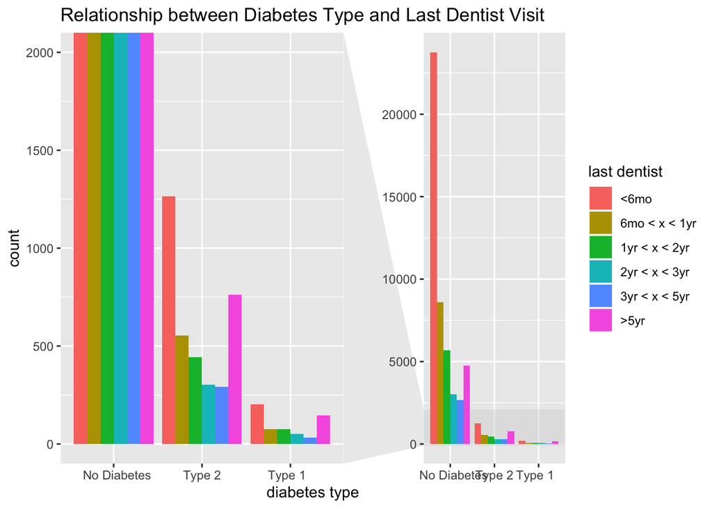

```r
ggplot(data = nhanes.never, aes(x = factor(diabetes_type),
                          y = stat(count),
                          fill = factor(last_dentist))) +
    geom_bar(position = "dodge") +
    facet_zoom(ylim = c(0, 2000)) +
    labs(x = 'diabetes type', y = 'count', fill = 'last dentist') +
    ggtitle("Relationship between Diabetes Type and Last Dentist Visit")
```

```r
nhanes.data.last.dentist <- nhanes.data %>%
  group_by(diabetes_type, last_dentist) %>%
  summarise(n = n()) %>%
  mutate(percent_per_factor = n/sum(n) * 100) %>%
  select(percent_per_factor, diabetes_type, last_dentist)

knitr::kable(nhanes.data.last.dentist, col.names = c("Percent  ",
                           "Diabetes type   ", "   Last Dentist"), align = "lll")
```

| Percent | Diabetes type | Last Dentist |
| --- | --- | --- |
| 29.3298434 | No Diabetes | <6mo |
| 10.6165737 | No Diabetes | 6mo < x < 1yr |
| 7.0262729 | No Diabetes | 1yr < x < 2yr |
| 3.7162329 | No Diabetes | 2yr < x < 3yr |
| 3.2915206 | No Diabetes | 3yr < x < 5yr |
| 5.8842412 | No Diabetes | >5yr |
| 5.0940787 | No Diabetes | Never |
| 0.0123463 | No Diabetes | Refused |
| 0.1518594 | No Diabetes | Don’t know |
| 34.8770310 | No Diabetes | NA |
| 24.0807773 | Type 2 | <6mo |
| 10.5353401 | Type 2 | 6mo < x < 1yr |
| 8.4206516 | Type 2 | 1yr < x < 2yr |
| 5.7915793 | Type 2 | 2yr < x < 3yr |
| 5.5629644 | Type 2 | 3yr < x < 5yr |
| 14.4979996 | Type 2 | >5yr |
| 1.2002286 | Type 2 | Never |
| 0.0190512 | Type 2 | Refused |
| 0.1333587 | Type 2 | Don’t know |
| 29.7580492 | Type 2 | NA |
| 28.9586305 | Type 1 | <6mo |
| 10.6990014 | Type 1 | 6mo < x < 1yr |
| 10.8416548 | Type 1 | 1yr < x < 2yr |
| 7.2753210 | Type 1 | 2yr < x < 3yr |
| 4.7075606 | Type 1 | 3yr < x < 5yr |
| 20.8273894 | Type 1 | >5yr |
| 0.9985735 | Type 1 | Never |
| 0.2853067 | Type 1 | Don’t know |
| 15.4065621 | Type 1 | NA |

```r
summary(glm(last_dentist ~ diabetes_type, data = nhanes.data, family = binomial(logit)))
```

```
##
## Call:
## glm(formula = last_dentist ~ diabetes_type, family = binomial(logit),
##     data = nhanes.data)
##
## Deviance Residuals:
##    Min      1Q  Median      3Q     Max
## -1.464  -1.263   1.094   1.094   1.094
##
## Coefficients:
##                       Estimate Std. Error z value Pr(>|z|)
## (Intercept)           0.199150   0.008751  22.756  < 2e-16 ***
## diabetes_type Type 2  0.451575   0.035783  12.620  < 2e-16 ***
## diabetes_typeType 1   0.453790   0.086987   5.217 1.82e-07 ***
## ---
## Signif. codes:  0 '***' 0.001 '**' 0.01 '*' 0.05 '.' 0.1 ' ' 1
##
## (Dispersion parameter for binomial family taken to be 1)
##
##     Null deviance: 78295  on 57026  degrees of freedom
## Residual deviance: 78105  on 57024  degrees of freedom
##   (29919 observations deleted due to missingness)
## AIC: 78111
##
## Number of Fisher Scoring iterations: 4
```

More people with diabetes have not been to the dentist in a while so this could possibly be a co-variate. To test, I once again removed those who hadn’t been to the dentist in a while and reran the boxplot and regression.

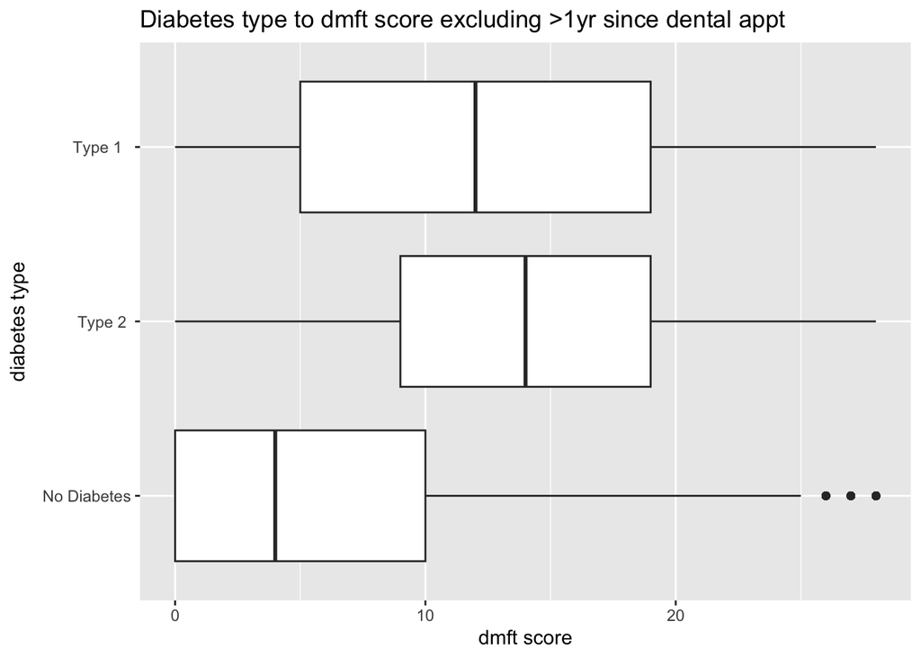

```r
nhanes.dentist <- nhanes.data %>%
  dplyr::filter(last_dentist == "<6mo" | last_dentist == "6mo < x < 1yr")

ggplot(data = nhanes.dentist, aes(dmft2, diabetes_type)) +
    geom_boxplot() +
    ggtitle("Diabetes type to dmft score excluding >1yr since dental appt")+
    labs(y= "diabetes type", x = "dmft score")
```

```r
summary(glm(last_dentist ~ diabetes_type, data = nhanes.dentist, family = binomial(logit)))
```

```
##
## Call:
## glm(formula = last_dentist ~ diabetes_type, family = binomial(logit),
##     data = nhanes.dentist)
##
## Deviance Residuals:
##    Min      1Q  Median      3Q     Max
## -0.852  -0.786  -0.786   1.619   1.628
##
## Coefficients:
##                       Estimate Std. Error z value Pr(>|z|)
## (Intercept)           -1.01619    0.01259 -80.745  < 2e-16 ***
## diabetes_type Type 2   0.18951    0.05252   3.609 0.000308 ***
## diabetes_typeType 1    0.02047    0.13571   0.151 0.880099
## ---
## Signif. codes:  0 '***' 0.001 '**' 0.01 '*' 0.05 '.' 0.1 ' ' 1
##
## (Dispersion parameter for binomial family taken to be 1)
##
##     Null deviance: 40038  on 34449  degrees of freedom
## Residual deviance: 40025  on 34447  degrees of freedom
## AIC: 40031
##
## Number of Fisher Scoring iterations: 4
```

Three different regression models were compared for diabetes and last dentist as a co-variate.

```r
lm1 <- lm(dmft2 ~ diabetes_type, data = nhanes.data)
lm2 <- lm(dmft2 ~ diabetes_type + last_dentist, data = nhanes.data)
lm3 <- lm(dmft2 ~ diabetes_type + last_dentist + last_dentist:diabetes_type, data = nhanes.data)

modelsummary(list(lm1, lm2, lm3), coef_omit = "Intercept",
             statistic = c("p = {p.value}"),
             estimate = "{estimate} [{conf.low}, {conf.high}]")
```

|  | Model 1 | Model 2 | Model 3 |
| --- | --- | --- | --- |
| diabetes_type Type 2 | 7.994 [7.716, 8.272] | 7.109 [6.840, 7.378] | 7.897 [7.457, 8.338] |
|  | p = <0.001 | p = <0.001 | p = <0.001 |
| diabetes_typeType 1 | 7.915 [7.215, 8.615] | 6.897 [6.223, 7.572] | 6.502 [5.405, 7.598] |
|  | p = <0.001 | p = <0.001 | p = <0.001 |
| last_dentist6mo < x < 1yr |  | −0.148 [−0.329, 0.033] | −0.099 [−0.285, 0.088] |
|  |  | p = 0.108 | p = 0.300 |
| last_dentist1yr < x < 2yr |  | 0.680 [0.468, 0.892] | 0.711 [0.491, 0.931] |
|  |  | p = <0.001 | p = <0.001 |
| last_dentist2yr < x < 3yr |  | 1.421 [1.143, 1.699] | 1.553 [1.262, 1.845] |
|  |  | p = <0.001 | p = <0.001 |
| last_dentist3yr < x < 5yr |  | 2.031 [1.736, 2.326] | 2.173 [1.863, 2.483] |
|  |  | p = <0.001 | p = <0.001 |
| last_dentist>5yr |  | 4.191 [3.957, 4.424] | 4.258 [4.008, 4.508] |
|  |  | p = <0.001 | p = <0.001 |
| last_dentistNever |  | −5.321 [−5.566, −5.076] | −5.287 [−5.535, −5.040] |
|  |  | p = <0.001 | p = <0.001 |
| last_dentistRefused |  | 4.162 [−1.481, 9.804] | 4.196 [−1.446, 9.837] |
|  |  | p = 0.148 | p = 0.145 |
| last_dentistDon’t know |  | −0.541 [−1.886, 0.805] | −0.514 [−1.899, 0.870] |
|  |  | p = 0.431 | p = 0.467 |
| diabetes_type Type 2 × last_dentist6mo < x < 1yr |  |  | −0.917 [−1.732, −0.101] |
|  |  |  | p = 0.028 |
| diabetes_typeType 1 × last_dentist6mo < x < 1yr |  |  | −0.915 [−3.113, 1.282] |
|  |  |  | p = 0.414 |
| diabetes_type Type 2 × last_dentist1yr < x < 2yr |  |  | −0.763 [−1.642, 0.115] |
|  |  |  | p = 0.088 |
| diabetes_typeType 1 × last_dentist1yr < x < 2yr |  |  | 0.501 [−1.670, 2.672] |
|  |  |  | p = 0.651 |
| diabetes_type Type 2 × last_dentist2yr < x < 3yr |  |  | −1.975 [−3.020, −0.930] |
|  |  |  | p = <0.001 |
| diabetes_typeType 1 × last_dentist2yr < x < 3yr |  |  | 0.418 [−2.147, 2.983] |
|  |  |  | p = 0.749 |
| diabetes_type Type 2 × last_dentist3yr < x < 5yr |  |  | −1.884 [−2.960, −0.809] |
|  |  |  | p = <0.001 |
| diabetes_typeType 1 × last_dentist3yr < x < 5yr |  |  | −0.719 [−3.815, 2.378] |
|  |  |  | p = 0.649 |
| diabetes_type Type 2 × last_dentist>5yr |  |  | −1.379 [−2.162, −0.597] |
|  |  |  | p = <0.001 |
| diabetes_typeType 1 × last_dentist>5yr |  |  | 2.229 [0.404, 4.054] |
|  |  |  | p = 0.017 |
| diabetes_type Type 2 × last_dentistNever |  |  | −0.554 [−2.570, 1.461] |
|  |  |  | p = 0.590 |
| diabetes_typeType 1 × last_dentistNever |  |  | −1.919 [−8.198, 4.360] |
|  |  |  | p = 0.549 |
| diabetes_type Type 2 × last_dentistDon’t know |  |  | 1.313 [−5.034, 7.659] |
|  |  |  | p = 0.685 |
| diabetes_typeType 1 × last_dentistDon’t know |  |  | −9.292 [−23.220, 4.636] |
|  |  |  | p = 0.191 |
| Num.Obs. | 48584 | 48581 | 48581 |
| R2 | 0.069 | 0.138 | 0.139 |
| R2 Adj. | 0.069 | 0.138 | 0.139 |
| AIC | 331390.9 | 327649.6 | 327638.8 |
| BIC | 331426.0 | 327755.1 | 327867.3 |
| Log.Lik. | −165691.430 | −163812.816 | −163793.378 |
| RMSE | 7.33 | 7.05 | 7.05 |

# Conclusion

This report demonstrates that there is a significant relationship between dental health and diabetes. This exists across measures of dental health such as dmft score, gum disease, loose teeth, bone loss, and difficulty with daily tasks due to teeth aching. In all measured variables, both diabetes type 1 and type 2 were statistically significantly worse than for patients without diabetes. However, type 1 and type 2 were not statistically significant between each other.

Future directions of this research could focus on investigating the relationship between other health outcomes and diabetes type to see if there is a difference in the manifestation of the disease in common health outcomes.

# References

1. Rovner AJ, Nansel TR. Are children with type 1 diabetes consuming a healthful diet?: a review of the current evidence and strategies for dietary change. Diabetes Educ. 2009 Jan-Feb;35(1):97-107. doi: 10.1177/0145721708326699. PMID: 19244565; PMCID: PMC2772111.
2. Husband AC, Crawford S, McCoy LA, Pacaud D. The effectiveness of glucose, sucrose, and fructose in treating hypoglycemia in children with type 1 diabetes. Pediatr Diabetes. 2010 May;11(3):154-8. doi: 10.1111/j.1399-5448.2009.00558.x. Epub 2009 Aug 3. PMID: 19663922.
3. Centers for Disease Control and Prevention. (2021, May 7). Diabetes and Oral Health. Centers for Disease Control and Prevention. Retrieved November 1, 2022, from https://www.cdc.gov/diabetes/managing/diabetes-oral-health.html
4. https://www.henryford.com/blog/2017/12/type-1-type-2-diabetes-difference
5. https://www.who.int/data/gho/indicator-metadata-registry/imr-details/3812#:~:text=Definition%3A,the%20sum%20of%20the%20population.
6. Sheetal A, Hiremath VK, Patil AG, Sajjansetty S, Kumar SR. Malnutrition and its oral outcome - a review. J Clin Diagn Res. 2013 Jan;7(1):178-80. doi: 10.7860/JCDR/2012/5104.2702. Epub 2013 Jan 1. PMID: 23449967; PMCID: PMC3576783.